# Supervised Learning - Foundations: ReCell

*Marks: 60*

## Context

Buying and selling used phones and tablets used to be something that happened on a handful of online marketplace sites. But the used and refurbished device market has grown considerably over the past decade, and a new IDC (International Data Corporation) forecast predicts that the used phone market would be worth \$52.7bn by 2023 with a compound annual growth rate (CAGR) of 13.6% from 2018 to 2023. This growth can be attributed to an uptick in demand for used phones and tablets that offer considerable savings compared with new models.

Refurbished and used devices continue to provide cost-effective alternatives to both consumers and businesses that are looking to save money when purchasing one. There are plenty of other benefits associated with the used device market. Used and refurbished devices can be sold with warranties and can also be insured with proof of purchase. Third-party vendors/platforms, such as Verizon, Amazon, etc., provide attractive offers to customers for refurbished devices. Maximizing the longevity of devices through second-hand trade also reduces their environmental impact and helps in recycling and reducing waste. The impact of the COVID-19 outbreak may further boost this segment as consumers cut back on discretionary spending and buy phones and tablets only for immediate needs.

## Objective

The rising potential of this comparatively under-the-radar market fuels the need for an ML-based solution to develop a dynamic pricing strategy for used and refurbished devices. ReCell, a startup aiming to tap the potential in this market, has hired you as a data scientist. They want you to analyze the data provided and build a linear regression model to predict the price of a used phone/tablet and identify factors that significantly influence it.

## Data Description

The data contains the different attributes of used/refurbished phones and tablets. The detailed data dictionary is given below.

**Data Dictionary**

- brand_name: Name of manufacturing brand
- os: OS on which the device runs
- screen_size: Size of the screen in cm
- 4g: Whether 4G is available or not
- 5g: Whether 5G is available or not
- main_camera_mp: Resolution of the rear camera in megapixels
- selfie_camera_mp: Resolution of the front camera in megapixels
- int_memory: Amount of internal memory (ROM) in GB
- ram: Amount of RAM in GB
- battery: Energy capacity of the device battery in mAh
- weight: Weight of the device in grams
- release_year: Year when the device model was released
- days_used: Number of days the used/refurbished device has been used
- new_price: Price of a new device of the same model in euros
- used_price: Price of the used/refurbished device in euros

## Importing necessary libraries and data

```python
# this will help in making the Python code more structured automatically (good coding practice)
!pip install nb_black
%load_ext nb_black

# Libraries to help with reading and manipulating data
import numpy as np
import pandas as pd

# Libraries to help with data visualization
import matplotlib.pyplot as plt
import seaborn as sns

sns.set()

# Removes the limit for the number of displayed columns
pd.set_option("display.max_columns", None)
# Sets the limit for the number of displayed rows
pd.set_option("display.max_rows", 200)

# to split the data into train and test
from sklearn.model_selection import train_test_split

# to build linear regression_model
import statsmodels.api as sm

# to check model performance
from sklearn.metrics import mean_absolute_error, mean_squared_error, r2_score
```

## Data Overview

- Observations
- Sanity checks

```python
# to load the dataset
data = pd.read_csv("used_device_data.csv")
```

```python
# checking the shape of the data
print(f"There are {data.shape[0]} rows and {data.shape[1]} columns.")  # f-string
```

```
There are 3454 rows and 15 columns.
```

```python
# to view a sample of the data and to set the ramdom_state so we will see the same samples
# every time running this code
data.sample(10, random_state=1)
```

|  | brand_name | os | screen_size | 4g | 5g | main_camera_mp | selfie_camera_mp | int_memory | ram | battery | weight | release_year | days_used | new_price | used_price |
| --- | --- | --- | --- | --- | --- | --- | --- | --- | --- | --- | --- | --- | --- | --- | --- |
| 866 | Others | Android | 15.24 | no | no | 8.00 | 2.0 | 16.0 | 4.00 | 3000.0 | 206.0 | 2014 | 632 | 179.61 | 56.76 |
| 957 | Celkon | Android | 10.16 | no | no | 3.15 | 0.3 | 512.0 | 0.25 | 1400.0 | 140.0 | 2013 | 637 | 48.65 | 16.45 |
| 280 | Infinix | Android | 15.39 | yes | no | NaN | 8.0 | 32.0 | 2.00 | 5000.0 | 185.0 | 2020 | 329 | 88.88 | 79.10 |
| 2150 | Oppo | Android | 12.83 | yes | no | 13.00 | 16.0 | 64.0 | 4.00 | 3200.0 | 148.0 | 2017 | 648 | 281.30 | 107.54 |
| 93 | LG | Android | 15.29 | yes | no | 13.00 | 5.0 | 32.0 | 3.00 | 3500.0 | 179.0 | 2019 | 216 | 200.42 | 91.62 |
| 1040 | Gionee | Android | 12.83 | yes | no | 13.00 | 8.0 | 32.0 | 4.00 | 3150.0 | 166.0 | 2016 | 970 | 279.87 | 104.13 |
| 3170 | ZTE | Others | 10.16 | no | no | 3.15 | 5.0 | 16.0 | 4.00 | 1400.0 | 125.0 | 2014 | 1007 | 69.71 | 43.14 |
| 2742 | Sony | Android | 12.70 | yes | no | 20.70 | 2.0 | 16.0 | 4.00 | 3000.0 | 170.0 | 2013 | 1060 | 330.24 | 83.33 |
| 102 | Meizu | Android | 15.29 | yes | no | NaN | 20.0 | 128.0 | 6.00 | 3600.0 | 165.0 | 2019 | 332 | 420.17 | 142.51 |
| 1195 | HTC | Android | 10.29 | no | no | 8.00 | 2.0 | 32.0 | 4.00 | 2000.0 | 146.0 | 2015 | 892 | 131.50 | 68.57 |

```python
# to create a copy of the data set so the original data would stay the same
df = data.copy()

# to check for any duplicate values in the data
print(
    f"There is/are {df.duplicated().sum()} duplication value(s) in the data."
)  # f-string
```

```
There is/are 0 duplication value(s) in the data.
```

```python
# to check column Dtypes and the number of non-null values
df.info()
```

```
<class 'pandas.core.frame.DataFrame'>
RangeIndex: 3454 entries, 0 to 3453
Data columns (total 15 columns):
 #   Column            Non-Null Count  Dtype
---  ------            --------------  -----
 0   brand_name        3454 non-null   object
 1   os                3454 non-null   object
 2   screen_size       3454 non-null   float64
 3   4g                3454 non-null   object
 4   5g                3454 non-null   object
 5   main_camera_mp    3275 non-null   float64
 6   selfie_camera_mp  3452 non-null   float64
 7   int_memory        3450 non-null   float64
 8   ram               3450 non-null   float64
 9   battery           3448 non-null   float64
 10  weight            3447 non-null   float64
 11  release_year      3454 non-null   int64
 12  days_used         3454 non-null   int64
 13  new_price         3454 non-null   float64
 14  used_price        3454 non-null   float64
dtypes: float64(9), int64(2), object(4)
memory usage: 404.9+ KB
```

- There are many numberic columns (9 float and 2 int Dtypes).
- There are 4 str (object) columns.
- The Dependent variable,'used_price' columns, is float Dtype.
- 'main_camera_mp', 'selfie_cacmera_mp', 'int_memory', 'ram', 'battery', and 'weight' have some missing values.
- 'main_camera_mp' has the most missing values.

```python
# to check for missing values
df.isnull().sum()
```

```
brand_name            0
os                    0
screen_size           0
4g                    0
5g                    0
main_camera_mp      179
selfie_camera_mp      2
int_memory            4
ram                   4
battery               6
weight                7
release_year          0
days_used             0
new_price             0
used_price            0
dtype: int64
```

```python
# to review the statistical summary of the data
df.describe(include="all").T  # to reverse columns to rows and rows to columns
```

|  | count | unique | top | freq | mean | std | min | 25% | 50% | 75% | max |
| --- | --- | --- | --- | --- | --- | --- | --- | --- | --- | --- | --- |
| brand_name | 3454 | 34 | Others | 502 | NaN | NaN | NaN | NaN | NaN | NaN | NaN |
| os | 3454 | 4 | Android | 3214 | NaN | NaN | NaN | NaN | NaN | NaN | NaN |
| screen_size | 3454.0 | NaN | NaN | NaN | 13.713115 | 3.80528 | 5.08 | 12.7 | 12.83 | 15.34 | 30.71 |
| 4g | 3454 | 2 | yes | 2335 | NaN | NaN | NaN | NaN | NaN | NaN | NaN |
| 5g | 3454 | 2 | no | 3302 | NaN | NaN | NaN | NaN | NaN | NaN | NaN |
| main_camera_mp | 3275.0 | NaN | NaN | NaN | 9.460208 | 4.815461 | 0.08 | 5.0 | 8.0 | 13.0 | 48.0 |
| selfie_camera_mp | 3452.0 | NaN | NaN | NaN | 6.554229 | 6.970372 | 0.0 | 2.0 | 5.0 | 8.0 | 32.0 |
| int_memory | 3450.0 | NaN | NaN | NaN | 54.573099 | 84.972371 | 0.01 | 16.0 | 32.0 | 64.0 | 1024.0 |
| ram | 3450.0 | NaN | NaN | NaN | 4.036122 | 1.365105 | 0.02 | 4.0 | 4.0 | 4.0 | 12.0 |
| battery | 3448.0 | NaN | NaN | NaN | 3133.402697 | 1299.682844 | 500.0 | 2100.0 | 3000.0 | 4000.0 | 9720.0 |
| weight | 3447.0 | NaN | NaN | NaN | 182.751871 | 88.413228 | 69.0 | 142.0 | 160.0 | 185.0 | 855.0 |
| release_year | 3454.0 | NaN | NaN | NaN | 2015.965258 | 2.298455 | 2013.0 | 2014.0 | 2015.5 | 2018.0 | 2020.0 |
| days_used | 3454.0 | NaN | NaN | NaN | 674.869716 | 248.580166 | 91.0 | 533.5 | 690.5 | 868.75 | 1094.0 |
| new_price | 3454.0 | NaN | NaN | NaN | 237.038848 | 194.302782 | 18.2 | 120.3425 | 189.785 | 291.115 | 2560.2 |
| used_price | 3454.0 | NaN | NaN | NaN | 92.302936 | 54.701648 | 4.65 | 56.4825 | 81.87 | 116.245 | 749.52 |

## Exploratory Data Analysis (EDA)

- EDA is an important part of any project involving data.
- It is important to investigate and understand the data better before building a model with it.
- A few questions have been mentioned below which will help you approach the analysis in the right manner and generate insights from the data.
- A thorough analysis of the data, in addition to the questions mentioned below, should be done.

**Questions**:

## Univariate Analysis

```python
# function to plot a boxplot and a histogram along the same scale.


def histogram_boxplot(data, feature, figsize=(12, 7), kde=False, bins=None):
    """
    Boxplot and histogram combined

    data: dataframe
    feature: dataframe column
    figsize: size of figure (default (12,7))
    kde: whether to the show density curve (default False)
    bins: number of bins for histogram (default None)
    """
    f2, (ax_box2, ax_hist2) = plt.subplots(
        nrows=2,  # Number of rows of the subplot grid= 2
        sharex=True,  # x-axis will be shared among all subplots
        gridspec_kw={"height_ratios": (0.25, 0.75)},
        figsize=figsize,
    )  # creating the 2 subplots
    sns.boxplot(
        data=data, x=feature, ax=ax_box2, showmeans=True, color="violet"
    )  # boxplot will be created and a star will indicate the mean value of the column
    sns.histplot(
        data=data, x=feature, kde=kde, ax=ax_hist2, bins=bins, palette="winter"
    ) if bins else sns.histplot(
        data=data, x=feature, kde=kde, ax=ax_hist2
    )  # For histogram
    ax_hist2.axvline(
        data[feature].mean(), color="green", linestyle="--"
    )  # Add mean to the histogram
    ax_hist2.axvline(
        data[feature].median(), color="black", linestyle="-"
    )  # Add median to the histogram
```

```python
# function to create labeled barplots


def labeled_barplot(data, feature, perc=False, n=None):
    """
    Barplot with percentage at the top

    data: dataframe
    feature: dataframe column
    perc: whether to display percentages instead of count (default is False)
    n: displays the top n category levels (default is None, i.e., display all levels)
    """

    total = len(data[feature])  # length of the column
    count = data[feature].nunique()
    if n is None:
        plt.figure(figsize=(count + 1, 5))
    else:
        plt.figure(figsize=(n + 1, 5))

    plt.xticks(rotation=90, fontsize=15)
    ax = sns.countplot(
        data=data,
        x=feature,
        palette="Paired",
        order=data[feature].value_counts().index[:n].sort_values(),
    )

    for p in ax.patches:
        if perc == True:
            label = "{:.1f}%".format(
                100 * p.get_height() / total
            )  # percentage of each class of the category
        else:
            label = p.get_height()  # count of each level of the category

        x = p.get_x() + p.get_width() / 2  # width of the plot
        y = p.get_height()  # height of the plot

        ax.annotate(
            label,
            (x, y),
            ha="center",
            va="center",
            size=12,
            xytext=(0, 5),
            textcoords="offset points",
        )  # annotate the percentage

    plt.show()  # show the plot
```

#### Question 1: What does the distribution of used device prices look like?

### used_price

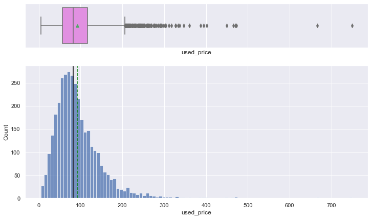

```python
histogram_boxplot(df, "used_price")
```

- There are a lot of outliners above 200 dollars to over 700 dollars.
- The 'used_price' distribution to heavily right-skewed.
- The mean is around 90 dollars and the median is 80 dollars.
- The mean is slidely higher than the median but they are very close.

#### Let's check if 'new_price' distribution is similarly to 'used_price'.

### new_price

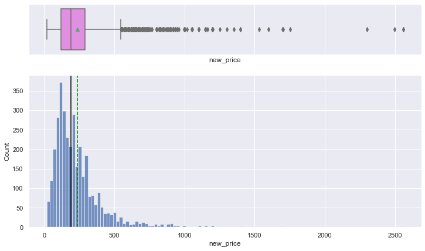

```python
histogram_boxplot(df, "new_price")
```

- The 'new_price'has a lot of outliners range from over 500 dollars to over 2500 dollars.
- The 'new_price' distribution is heavily right-skewed.
- The mean is higher than the mean.
- The 'new_price' distribution is very similar to the 'used_price'.

### 'screen_size'

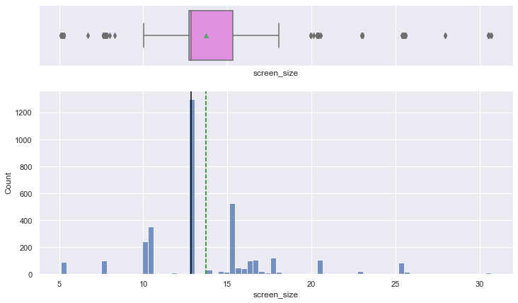

```python
histogram_boxplot(df, "screen_size")
```

- There are a lot of outliners outside min wisker and max wisker.
- The 'screen_size' distribution is very scatter with right-skewed.
- Mean is higher than median but median has the most value counts over 1200 units.

### 'main_camera_mp'

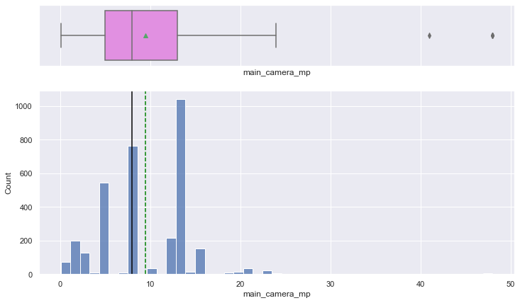

```python
histogram_boxplot(df, "main_camera_mp")
```

- The 'main_camera_mp' column has a righ-skewed distribution.
- Its mean is greater than its median.
- It has a few outliners.

### 'selfie_camera_mp'

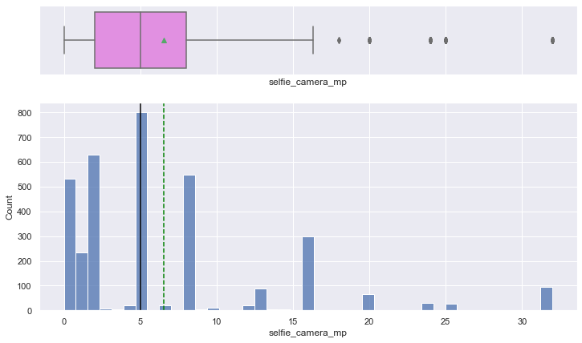

```python
histogram_boxplot(df, "selfie_camera_mp")
```

- The 'selfie_camera_mp' column also has a righ-skewed distribution.
- Its mean is greater than its median.
- It has a few outliners.

### 'int_memory'

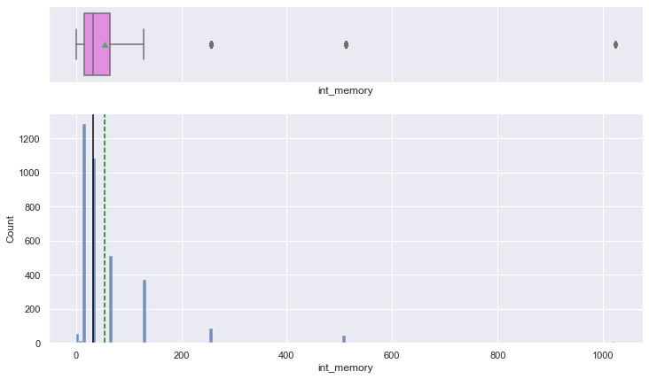

```python
histogram_boxplot(df, "int_memory")
```

- The 'int-memory' column also has a righ-skewed distribution.
- Its mean is greater than its median.
- It has a few outliners.

### 'ram'

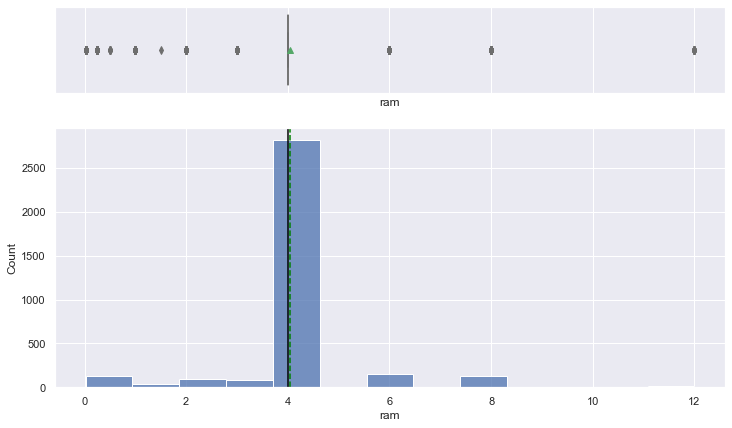

```python
histogram_boxplot(df, "ram")
```

- The 'ram' column distribution Q1 tp Q4 line on its mean and its median.
- Mean and median are very close.
- It has few outliners outside min wisker and max wisker.

### 'battery'

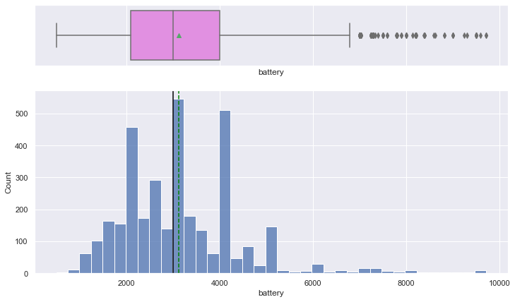

```python
histogram_boxplot(df, "battery")
```

- The 'battery' column also has a righ-skewed distribution.
- Its mean is greater than its median.
- It has some outliners over the max wisker.

### 'weight'

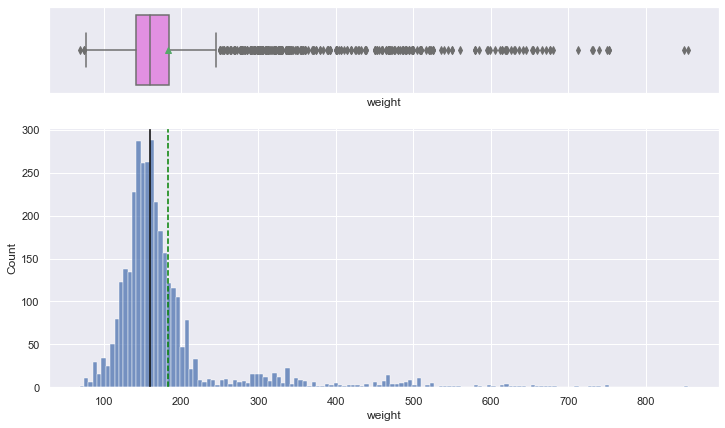

```python
histogram_boxplot(df, "weight")
```

- The 'weight' column also has a righ-skewed distribution.
- Its mean is greater than its median.
- It has lots od outliners over the max wisker.

### 'release_year'

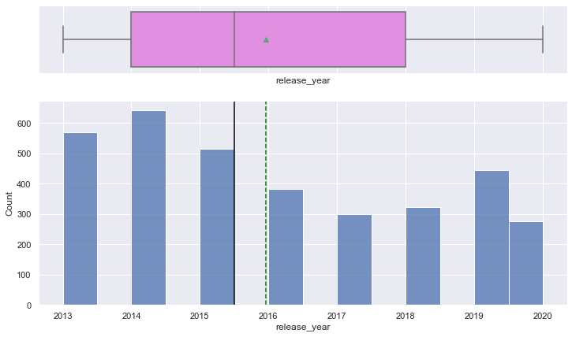

```python
histogram_boxplot(df, "release_year")
```

- The 'relase year' columns has a slightly right-skewed.
- The devices were relased from 2013-2020.
- The most popular years are 2014, 2013, 2015, 2019 in oder.
- Devices from 2020 have the lease amount in the market. It makes sense since they are still new.

### 'days_used'

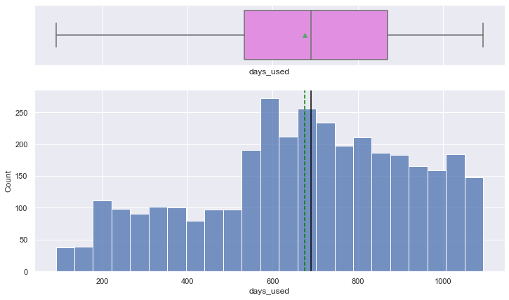

```python
histogram_boxplot(df, "days_used")
```

- The 'days used' distribution is left-skewed with mean is less than median.

### 'brand_name'

```python
df["brand_name"].value_counts().head()
```

```
Others     502
Samsung    341
Huawei     251
LG         201
Lenovo     171
Name: brand_name, dtype: int64
```

- For the top 5 brands, 'Others' has the most values, 502, then 'Samsung' 341, 'Huawei' 251, 'LG' 201, and 'Lenovo' 171.
- Do we need to discover more on 'Other' brands?

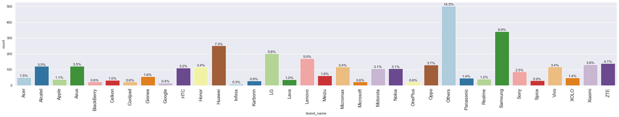

```python
labeled_barplot(df, "brand_name", perc=True)
```

#### Question 2: What percentage of the used device market is dominated by Android devices?

### 'os'

```python
df["os"].value_counts()  # returning munber of units per each operation system
```

```
Android    3214
Others      137
Windows      67
iOS          36
Name: os, dtype: int64
```

- For operational sytem. 'os', Android is an extreamly high values, 3214, comparing to the rest, others 137, Window 67, and iOS 36.

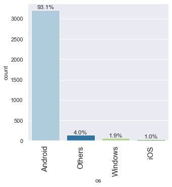

```python
labeled_barplot(df, "os", perc=True)
```

- Android os is 93.1% dominated the used device market.

### '4g'

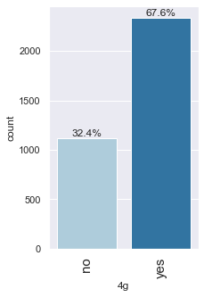

```python
labeled_barplot(df, "4g", perc=True)
```

- 67.6% of the devices has 4g service.

### '5g'

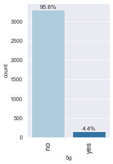

```python
labeled_barplot(df, "5g", perc=True)
```

- 95.6% of devices has no 5g service.

## Bivariate Analysis

#### Question 3. The amount of RAM is important for the smooth functioning of a device. How does the amount of RAM vary with the brand?

### 'ram' vs 'brand_name'

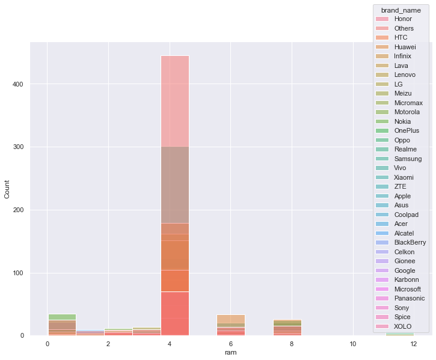

```python
# using brand_name as hue
plt.figure(figsize=(12, 9))
sns.histplot(data=df, x="ram", hue="brand_name")
plt.show()
```

- All the brands have variety size of RAM.
- Majority of devices have 4 RAM.
- No device has 10 RAM.

#### Let's check the relationship between 'ram' and 'used_price'

```python
df.groupby("ram")["used_price"].mean()  # returning mean of used price per each ram
```

```
ram
0.02      31.539444
0.03      30.154706
0.25      27.080602
0.50      34.504444
1.00      64.387059
1.50      75.650000
2.00      70.792667
3.00      86.920741
4.00      87.201545
6.00     155.039026
8.00     192.302615
12.00    280.710556
Name: used_price, dtype: float64
```

- RAM with 12 GB has the highest mean of used price at 280 dollars, followed by 8 GB at 192 dollars, and 6 GB at 155 dollars.

#### Question 4. A large battery often increases a device's weight, making it feel uncomfortable in the hands. How does the weight vary for phones and tablets offering large batteries (more than 4500 mAh)?

```python
# to create a new dataframe that contains "battery", "weight", and "used_price"
batt_weight = df[["battery", "weight", "used_price"]]
batt_weight = batt_weight[
    batt_weight.battery > 4500
]  # to only return rows with battery larger thab 4500 mAh
batt_weight.head()  # to check the dataframe
```

|  | battery | weight | used_price |
| --- | --- | --- | --- |
| 3 | 7250.0 | 480.0 | 169.93 |
| 4 | 5000.0 | 185.0 | 80.64 |
| 11 | 5000.0 | 185.0 | 105.36 |
| 19 | 5100.0 | 173.0 | 71.37 |
| 20 | 5100.0 | 173.0 | 95.23 |

### 'weight' vs 'battery'

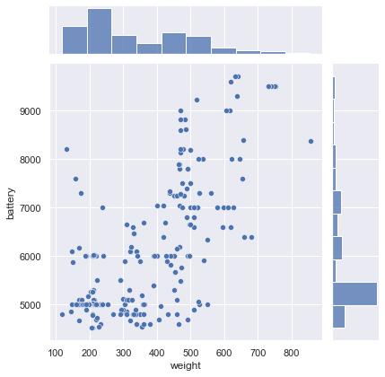

```python
# Relationship between weight and battery
plt.figure(figsize=(12, 7))
sns.jointplot(x="weight", y="battery", data=batt_weight)  # using batt_weight dataframe
plt.show()
```

- There is a trend that when a battery size increases and the weight of a device also increases.
- However, there are some exceptionals that when a battery size increases but the weight stays low. Or when a battery size does not increase but the weight does.
- The highest density is when battery sizes are around 5000-5500 mAh and the weightes are around 190-260 grams.

#### Let's check the relationship between 'battery' and 'used_price'.

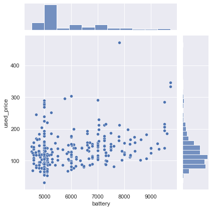

```python
# Relationship between weight and battery
plt.figure(figsize=(12, 7))
sns.jointplot(
    x="battery", y="used_price", data=batt_weight
)  # using batt_weight dataframe
plt.show()
```

- 5000 mAh has the highest density and has price range from less than 50 dollars to almost 300 dollars.
- The range of battery from 5000-9000 mAh has the highest density around 100 dollars.

#### Question 5: Bigger screens are desirable for entertainment purposes as they offer a better viewing experience. How many phones and tablets are available across different brands with a screen size larger than 6 inches?

```python
# to create a new dataframe that contains "brand_name" and "screen_size"
screen = df[["brand_name", "screen_size"]]
screen = screen[
    screen.screen_size > 6
]  # to return rows with screen_size larager than 6 inches
screen.head()
```

|  | brand_name | screen_size |
| --- | --- | --- |
| 0 | Honor | 14.50 |
| 1 | Honor | 17.30 |
| 2 | Honor | 16.69 |
| 3 | Honor | 25.50 |
| 4 | Honor | 15.32 |

```python
print(
    f"There are {screen.shape[0]} devices are available across different brands with a screen size larger than 6 inches."
)
```

[output not shown]

#### Let's check the relationship with 'weight' and 'used_price'

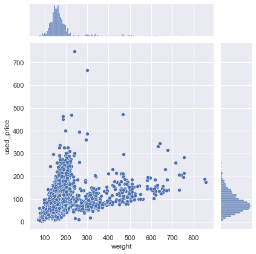

```python
# Relationship between weight and battery
plt.figure(figsize=(12, 7))
sns.jointplot(x="weight", y="used_price", data=df)
plt.show()
```

- The weight range from 100-200 grams is very denisity and has a great resale price range.
- There are two patterns that weight has possitive impact in resale price.
- It's possible that one pattern is for cellphones and another for tables.
- For devices to have great functionality, they would come with good camera, larger screen, good battery size, etc. These parts would cause the devices to weight more than devices with less functionality.

#### Question 6: Budget devices nowadays offer great selfie cameras, allowing us to capture our favorite moments with loved ones. What is the distribution of budget devices offering greater than 8MP selfie cameras across brands?

```python
# to create a new dataframe that contains "brand_name", "main_camera_mp", "selfie_camera_mp", and "used_price"
selfie = df[["brand_name", "main_camera_mp", "selfie_camera_mp", "used_price"]]
selfie = selfie[
    selfie.selfie_camera_mp > 8
]  # to return rows with selfie camera larger than 8 mp
selfie.head()  # to return the top 5 rows
```

|  | brand_name | main_camera_mp | selfie_camera_mp | used_price |
| --- | --- | --- | --- | --- |
| 1 | Honor | 13.0 | 16.0 | 174.53 |
| 8 | Honor | 13.0 | 16.0 | 132.43 |
| 12 | Honor | 13.0 | 16.0 | 217.73 |
| 13 | Honor | 13.0 | 16.0 | 101.25 |
| 16 | Honor | 13.0 | 32.0 | 151.77 |

```python
print(
    f"The mean of selfie camera of budget devices offering greater than 8MP is {round(selfie.selfie_camera_mp.mean(),2)}MP and the median is {round(selfie.selfie_camera_mp.median(),2)}MP."
)

print(
    f"The mean of main camera of budget devices offering greater than 8MP is {round(selfie.main_camera_mp.mean(),2)}MP and the median is {round(selfie.selfie_camera_mp.median(),2)}MP."
)
```

```
The mean of selfie camera of budget devices offering greater than 8MP is 18.75MP and the median is 16.0MP.
The mean of main camera of budget devices offering greater than 8MP is 12.14MP and the median is 16.0MP.
```

### 'selfie_camera_mp' vs 'brand_name'

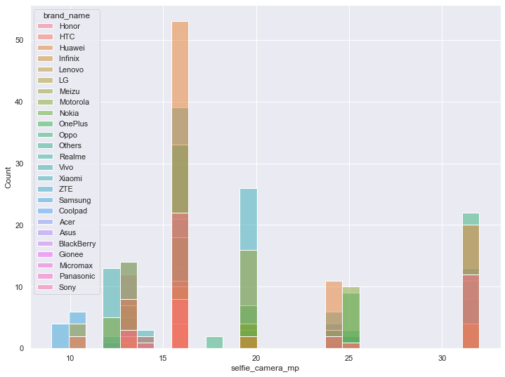

```python
# to graph using brand name as hue
plt.figure(figsize=(12, 9))
sns.histplot(data=selfie, x="selfie_camera_mp", hue="brand_name")
plt.show()
```

- The distribution of budget devices offering greater than 8MP selfie cameras across brands is right-skewed.
- The selfie camera with ~16MP has the highest count, over 50 devices.
- Then followed by the selfie camera ~19-20MP, almost 30 counts, and over 30MP, over 20 counts.

### 'selfie_camera_mp' vs 'used_price'

```python
# to return the mean of used price by the resolution of selfie camera from selfie dataframe
selfie.groupby("selfie_camera_mp")["used_price"].mean()
```

```
selfie_camera_mp
9.0     271.202500
10.0    180.176000
10.5    193.315000
12.0    139.270952
13.0    122.660000
14.0    125.353333
14.5    157.966000
16.0    146.746007
16.3    125.460000
18.0    110.485000
20.0    159.493582
24.0    175.304000
25.0    158.413214
32.0    182.510638
Name: used_price, dtype: float64
```

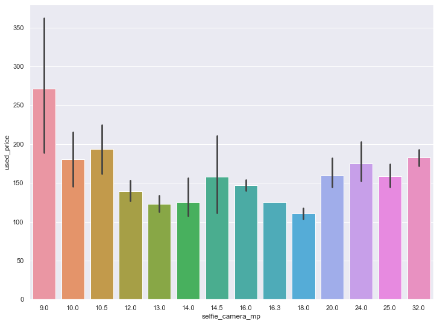

```python
# to graph numeric variables
plt.figure(figsize=(12, 9))
sns.barplot(data=selfie, x="selfie_camera_mp", y="used_price")
plt.show()
```

- The devices which have selfie camera 9.0 MP have a higher used price range than 10.0-32.0 MP.
- 9.0 MP mean of used price is 271 dollars.
- 10.5 MP mean of used price is 193 dollars.
- 32.0 MP mean of used price is 182 dollars.

Let's check the relationship between 'main_camera' with the used_price

```python
# to return the mean of used price by the resolution of main camera from selfie dataframe
selfie.groupby("main_camera_mp")["used_price"].mean()
```

```
main_camera_mp
0.3     151.460000
2.0     101.773333
5.0     132.129375
6.5      88.490000
8.0     159.734699
10.5    198.446923
12.0    164.220959
12.5     93.450000
13.0    144.371319
14.5    124.040000
16.0    145.898846
19.0    143.416000
20.0    129.130000
20.2    110.310000
21.2     99.610000
21.5    129.550000
23.0    138.096000
48.0    223.730000
Name: used_price, dtype: float64
```

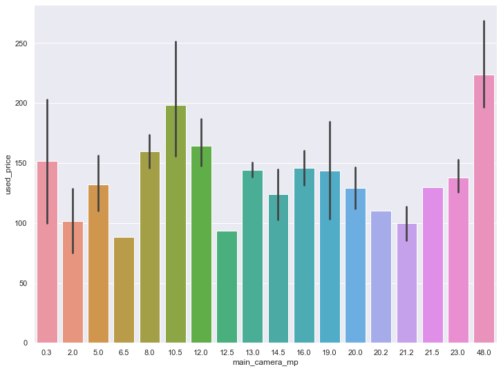

```python
# to graph numeric variables
plt.figure(figsize=(12, 9))
sns.barplot(data=selfie, x="main_camera_mp", y="used_price")
plt.show()
```

- For main_camera, the resolution of 48 MP has the highest used price with the mean at 223 dollars.
- Follow by 10.5 MP with the mean at 198 dollars.

#### Let's check the relationship bwtween 'int_memory' and 'used_price'

```python
# to return the mean of used price by the internal memory
df.groupby("int_memory")["used_price"].mean()
```

```
int_memory
0.01        22.140000
0.06        30.450000
0.10        32.797647
0.20        23.755000
0.50        14.825000
4.00        51.721000
8.00        52.180000
16.00       68.050164
24.00       23.370000
32.00       81.224377
64.00      121.792083
128.00     156.356532
256.00     164.664070
512.00     120.284545
1024.00    181.871250
Name: used_price, dtype: float64
```

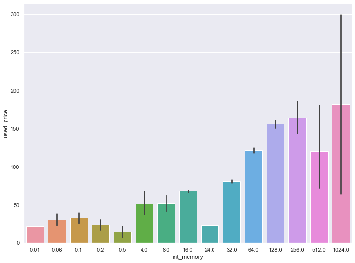

```python
# to graph numeric variables
plt.figure(figsize=(12, 9))
sns.barplot(data=df, x="int_memory", y="used_price")
plt.show()
```

- The internal memory of 1024 GB has the highest used price mean at 181 dollars.
- Follow by 256 GB with mean at 164 dollars and 128 GB with mean at 156 dollars.
- In contrast with the internal memory of 512 GB with mean at 120 dollars.

#### Question 7: Which attributes are highly correlated with the price of a used device?

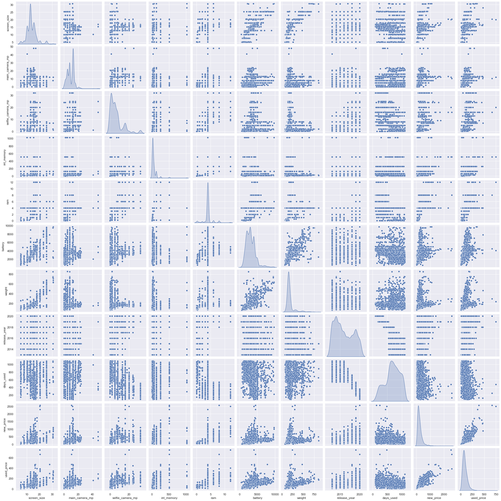

```python
sns.pairplot(
    df, diag_kind="kde"
)  # plots pairplot plots for every pair of attributes and showing Kernel density estimation
plt.show()
```

- Most of columns have positive correlation with used price except days used columns.
- The new price columns has the highest correlation with used price.

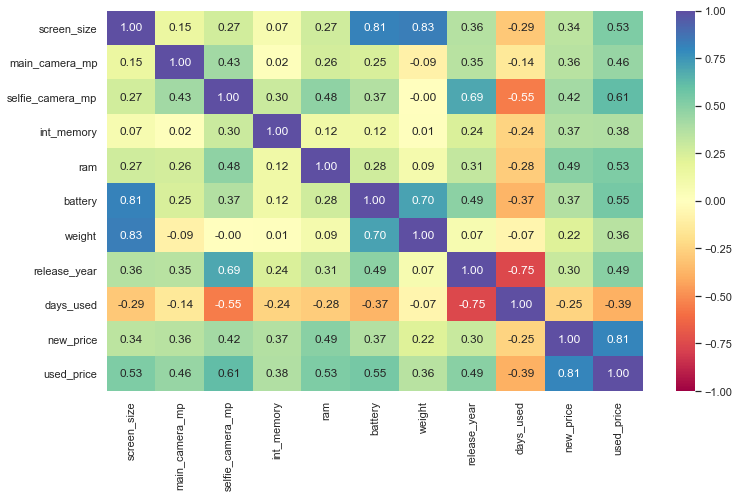

```python
# plots heatmap for correlation with 2 decimals for every pair of attributes
plt.figure(figsize=(12, 7))
sns.heatmap(df.corr(), annot=True, vmin=-1, vmax=1, fmt=".2f", cmap="Spectral")
plt.show()
```

- New priced of devices has 0.81 correlated with the price of a used device. The highest.
- The attributes below are also has a highly correlated with the price of a used device:
  - selfie camera, 0.61
  - battery, 0.55
  - screen size and ram, 0.53
- Number of days used has negatively correlated, - 0.39, to the used price.
- The least correlated to the used price is weight, at 0.36.
- Other columns with highly correlations:
  - Screen size and weight are correlated at 0.83.
  - Screen size and battery are correlated at 0.81.
  - Weight and battery are correlated at 0.70.
  - Release day and days used are correlated at -0.75.

### 'brand_name' vs 'used_price'

```python
# To check the mean of used price for each brand
df.groupby("brand_name")["used_price"].mean()
```

```
brand_name
Acer           73.611176
Alcatel        60.090496
Apple         172.015385
Asus           98.752295
BlackBerry     80.341364
Celkon         32.210909
Coolpad        84.915455
Gionee         88.591786
Google        138.597333
HTC            88.801273
Honor         114.489138
Huawei        122.436813
Infinix        81.126000
Karbonn        49.286552
LG             84.610149
Lava           51.867500
Lenovo         87.475380
Meizu         108.286935
Micromax       50.304957
Microsoft      75.838636
Motorola       91.343962
Nokia          61.760943
OnePlus       183.223636
Oppo          130.043566
Others         75.383606
Panasonic      71.296809
Realme        107.493171
Samsung       101.570059
Sony          101.721977
Spice          44.024333
Vivo          126.787094
XOLO           53.538571
Xiaomi        122.796288
ZTE            86.898286
Name: used_price, dtype: float64
```

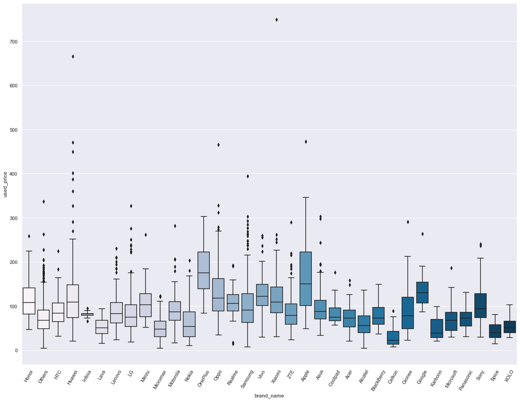

```python
# Relationship between used price and brand name
plt.figure(figsize=(20, 15))
sns.boxplot(x="brand_name", y="used_price", data=df, palette="PuBu")
plt.xticks(rotation=60)  # to rotate units on x-axis by 60 degrees
plt.show()
```

### 'os' vs 'used_price'

```python
# To check the median of used price for each brand since Android is dominate the market
df.groupby("os")["used_price"].median()
```

```
os
Android     83.44
Others      26.67
Windows     56.46
iOS        138.42
Name: used_price, dtype: float64
```

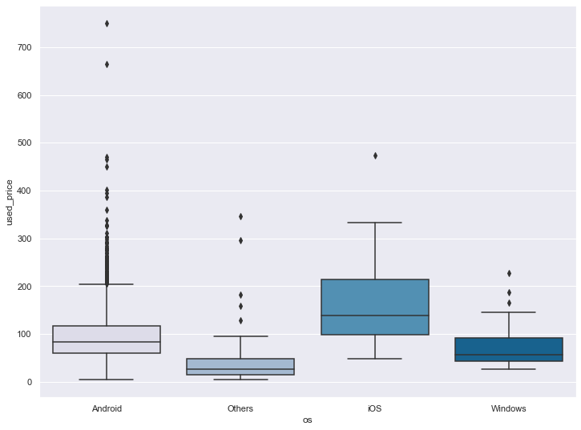

```python
# relationship between operation system and used price
plt.figure(figsize=(12, 9))
sns.boxplot(x="os", y="used_price", data=df, palette="PuBu")
# plt.xticks(rotation=60)
plt.show()
```

- iOS operation system has the highest median price 138 dollars and followed by Android 83 dollars, Windows 56 dollars, and others 26 dollars.
- Android has lots of outlines and it has the most outlines comparing to the rest.

### 'release_year' vs 'used_price'

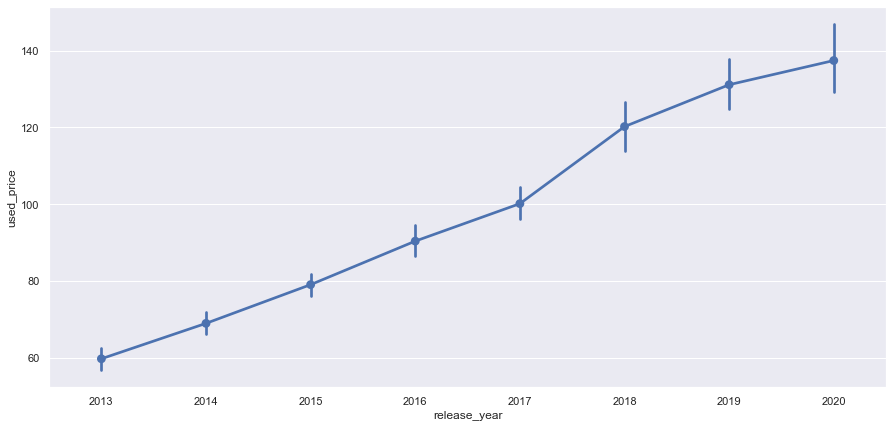

```python
# Relationship between release year and used price
plt.figure(figsize=(15, 7))
sns.pointplot(x="release_year", y="used_price", data=df)
plt.show()
```

### '4g', and 'used price'

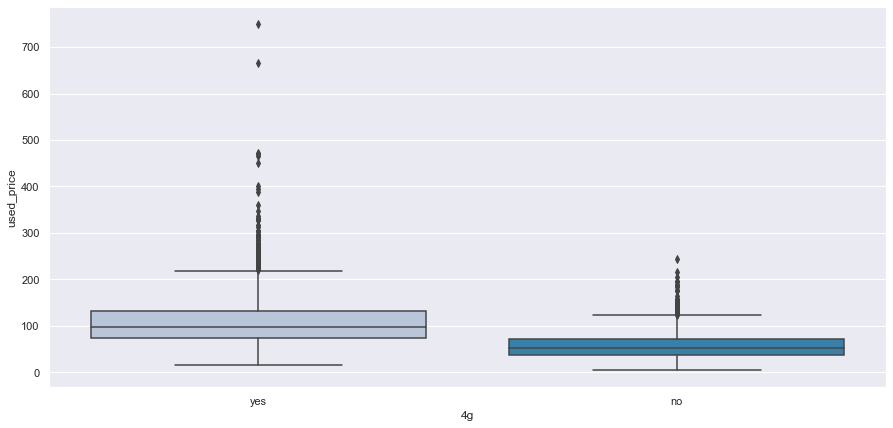

```python
# Relationship between 4g and used price
plt.figure(figsize=(15, 7))
sns.boxplot(x="4g", y="used_price", data=df, palette="PuBu")
# plt.xticks(rotation = 60)
plt.show()
```

- The devices with 4g, the used prices are higher than no

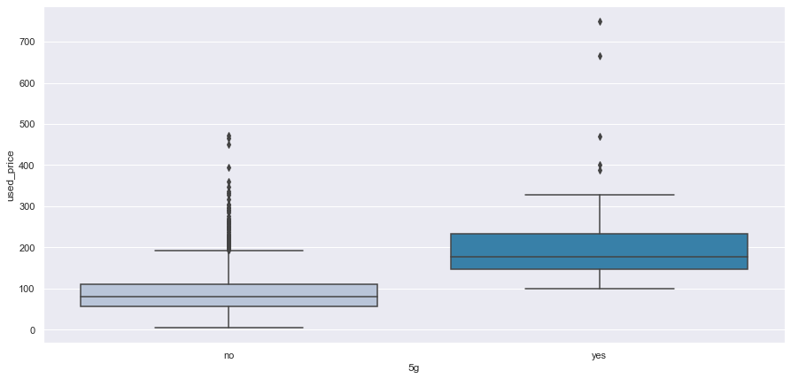

```python
# Relationship between 5g and used price
plt.figure(figsize=(15, 7))
sns.boxplot(x="5g", y="used_price", data=df, palette="PuBu")
# plt.xticks(rotation = 60)
plt.show()
```

- 5g devices have a higher used price range.
- There are a lot of outliners on devices with no 5g.